# 統計学2

ggplot2入門

矢内 勇生

2019-05-06（改訂：2019-05-09）

**2019-05-09 改訂：** Windows で図を保存する場合も、サイズをインチで指定するように変更 (units 引数が指定できなくなっていたので)。

# 今回の目標

- ggplot2 の使い方を覚えよう！

# ggplot2の基礎

## ggplot2 とは何か

**ggplot2** は、Rで**綺麗な**図を作るためのパッケージである。 RStudio のChief Scientist である [Hadley Wickham](http://hadley.nz/) が大学院生時代に開発・公開し、アップデートを重ねてきたものである（Hadley は **tidyverse** などの重要パッケージ開発の中心人物であり、世界中のRユーザから最も尊敬されている人物だと考えられる。日本の一部のRユーザは彼を「羽鳥先生」と呼ぶ）。

ggplot2 の *gg* は **g**rammar of **g**raphics（図のための文法） という意味で、一貫した方法で様々な図が作れるように工夫されている。 最初は文法を覚えるのに少し苦労するかもしれない。しかし、一度文法を身につけてしまえば、様々な図を簡単に作れるようになるので、とても便利である。また、デフォルト（既定）の設定でそれなりに綺麗な図が作れるのも魅力である（某表計算ソフトのように、何も考えずに 3D棒グラフのような醜い図を作ってしまうということが防げる）。

ggplot2 についての詳しい説明は、Hadley自身が書いた *ggplot2: Elegant Graphics for Data Analysis, 2nd ed.* (Springer) で読める（[PDFファイル](https://www.dropbox.com/s/0lap7tr7zoryyjk/ggplot2-book.pdf?dl=0) が無料で公開されている）。

また、チートシート（[日本語版](https://t.co/kf1jHrZlsa); [英語版](https://github.com/rstudio/cheatsheets/raw/master/data-visualization-2.1.pdf)）が公開されているので、ダウンロードしていつでも見られるようにしておくと、便利である。

## ggplot2 パッケージの読み込み

今回利用するパッケージを読み込む。**ggplot2**は **tidyverse** に含まれているので、`library()` で **tidyverse** を読み込めばよい。パッケージをインストール済みでない場合は、読み込みの前にまず`install.packages()` でインストールする。

```r
#install.packages("tidyverse", dependencies = TRUE)
library("tidyverse")
```

**Macユーザのみ**次のコードも実行する（Windowsユーザは実行しない）。

```r
theme_set(theme_gray(base_size = 10, base_family = "HiraginoSans-W3"))
```

## ggplotの基本的な使い方

### データフレーム

ggplot2 で図を作るためには、**データフレーム (data frame)** と呼ばれる形式のデータが必要である。 `readr::read_csv()` や `read.csv()` などでデータを読み込めば、データフレームができる。

例として、これまでの授業でも使った fake-data-01.csv を読み込んでみよう。プロジェクト内の data ディレクトリ（フォルダ）に fake-data-01.csv があることを想定している。

```r
myd <- read_csv("data/fake-data-01.csv")
```

これがデータフレームかどうか確かめるために、`is.data.frame()` を使う。

```r
is.data.frame(myd)
```

```
## [1] TRUE
```

**TRUE** （真）という答えが返され、myd がデータフレームであることがわかる。

また、データフレームは、`data.frame()` で作ることもできる。データフレームの代わりに**tibble** と呼ばれる形式のデータを使うこともできる。tibble は、`tibble::tibble()` で作れる。

練習のために、df1という名前のデータフレームと、df2という名前のtibble を作ってみよう。まず、x とy という二つの変数をもつdf1 を作る。

```r
df1 <- data.frame(x = 1:10, y = 10:1)
is.data.frame(df1)
```

```
## [1] TRUE
```

次に、v1, v2, v3 という3つの変数をもつ df2 を作る。`rnorm(n, mean, sd)` で、平均がmean、標準偏差がsd の正規分布から n個の乱数を生成することができる（詳しくは、今後の授業で説明する）。

```r
df2 <- tibble(v1 = rnorm(100, mean = 0, sd = 5),
              v2 = rnorm(100, mean = -4, sd = 5),
              v3 = rnorm(100, mean = 0, sd = 1))
is.data.frame(df2)
```

```
## [1] TRUE
```

df1とdf2の両者が “data.frame” （データフレーム）であることが確認できた。特に`data.frame()` の方を好む理由がなければ、今後は `tibble()` でデータフレーム (tibble) を作ろう。

それぞれの中身を確認してみよう。

```r
glimpse(df1)
```

```
## Observations: 10
## Variables: 2
## $ x <int> 1, 2, 3, 4, 5, 6, 7, 8, 9, 10
## $ y <int> 10, 9, 8, 7, 6, 5, 4, 3, 2, 1
```

```r
glimpse(df2)
```

```
## Observations: 100
## Variables: 3
## $ v1 <dbl> -0.3464615, 11.4498748, 1.7233224, -0.3811057, -5.2453548, -5…
## $ v2 <dbl> 2.4065593, -4.7917496, -8.8178080, -9.9918170, -0.7096655, -6…
## $ v3 <dbl> 0.08949345, -0.19456871, 1.07364719, -0.15110109, 0.08577871,…
```

MS Excel等で見慣れたスプレッドシート形式でデータの中身を確認したいときは、`View()` を使う（この関数は R Markdown ファイルではなく、Console に直接入力する方がいい）。 例えば、

```r
View(df2)
```

とすると、スプレッドシートが表示される。データの中身を確認できたら、スプレッドシートは閉じよう。

### `ggplot()`

ggplot2パッケージを使った作図でまず使うのが、`ggplot2::ggplot()` という関数である。 この関数は、データフレームを第1引数にとる。

例えば、

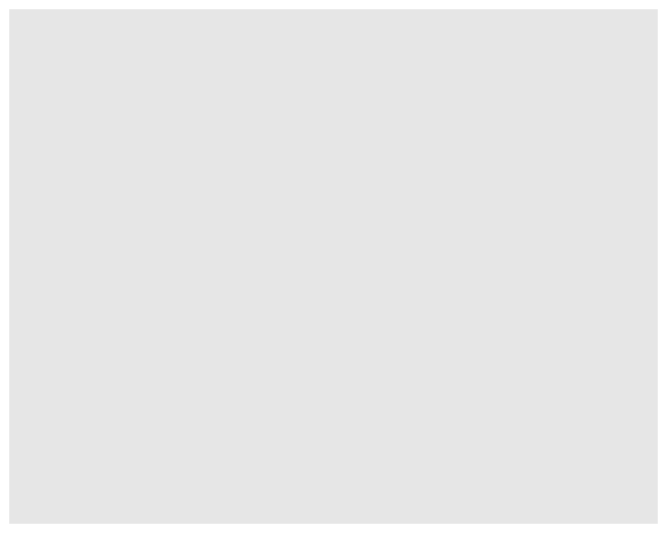

```r
ggplot(df1)
```

のように使う。ただし、データフレームを指定しただけでは、図はできない。

### `geom_xxx()`

図を作るためには、`geom_xxx()` のように、**geom** から始まる関数で新たな層 (layer) を加える必要がある。geom とは geometry（形状）のことである。例えば、ヒストグラム (histogram) を作るときは`geom_histogram()` を、箱ひげ図 (box[-and-whisker] plot) を作るときは `geom_boxplot()` を使う。

例として、df2 の変数のヒストグラムを作ってみよう。 まず、df2を`ggplot()` に渡し、その結果を h1 としてよう。

```r
h1 <- ggplot(df2)
```

次に、ヒストグラムの層を加える。df2にはv1, v2, v3 という3つの変数があるので、どの変数を図にするかを指定する必要がある。作図に用いる変数の指定は、`aes()` で行う。aes とは aesthetics（美感）のことである。この `aes()` の指定の仕方は、作る図によって異なる。したがって、ggplot2 の使い方をマスターするには、geom ごとに異なるaes の使い方を覚える必要がある。覚えるといっても、必ずしも暗記する必要なない。頻繁に使うものは覚えた方が楽（自然に覚える）が、その他のものについては、チートシート（[日本語版](https://t.co/kf1jHrZlsa); [英語版](https://github.com/rstudio/cheatsheets/raw/master/data-visualization-2.1.pdf)）やインターネット上にまとめられた情報（例えば、[ココ](https://qiita.com/yutannihilation/items/e1b9249541fc57b60705) や[ココ](https://ggplot2.tidyverse.org/reference/)）で確認すればよい。

例として、ヒストグラムを作ってみよう。縦軸が度数 (count, frequency) のヒストグラムを作るには、`aes()` の **x** を指定する。次のようにして、先ほど作った h1 にv1 のヒストグラムの層を加え、h2と名前をつけよう。

```r
h2 <- h1 + geom_histogram(aes(x = v1))
```

これでヒストグラムができているはずだ。作ったヒストグラムを表示するには、`plot()` または `print()` を使う。

```r
plot(h2)
```

[output not shown]

このように、ggplot2を使った基本的な作図は、3つのステップでできる。

1. `ggplot()` にデータフレームを渡す。
2. 作りたい図の `geom_xxx()` 層を加える。
3. `plot()` または `print()` で作った図を表示する。

ステップ1とステップ2は同時に実行できる。そのためには、次のようにする。

```r
h3 <- ggplot(df2) +
    geom_histogram(aes(x = v1))
```

コードを読みやすくするために、このコードのように**`+` の直後で改行することを強く勧める**。RStduioは、2行目以降も一つの命令が続いていることが一目でわかるよう、2行目以降を字下げ (indent) して表示してくれる。

確認のため、h3を表示する。

```r
print(h3)
```

[output not shown]

先ほどと同じ図ができた。

また、`aes()` の指定は、`ggplot()` の中で行うこともできる。例えば、次の方法で上と同じ図ができる。

```r
h4 <- ggplot(df2, aes(x = v1)) +
    geom_histogram()
```

確認してみよう。

```r
plot(h4)
```

[output not shown]

再び同じ図ができた。

### `labs()`

ここまでで図の中身はできた。しかし、論文やレポートなどで図を使うときには、軸ラベルまで思い通りにコントロールする必要がある。日本語で文章を書いているなら、図のラベルも日本語にする方が親切だろう。

(**注：** RStudio Cloud では、図の中で日本語が使えないようである。)

ラベルの変更は、`labs()` で行う。仮に、v1 という変数が「クラス1の得点」を表しているとして、h4の軸ラベルを変更してみよう。

```r
h5 <- h4 + labs(x = "クラス1の得点", y = "度数")
```

表示してみよう。

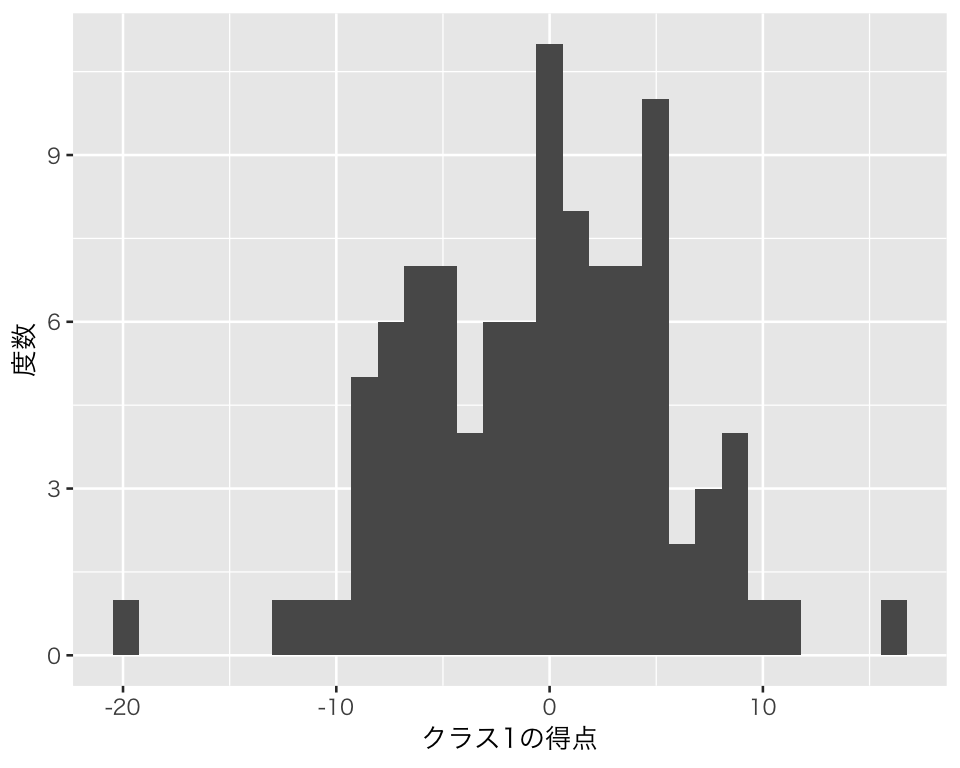

```r
plot(h5)
```

軸ラベルも、作図と同時に加えることができる。軸ラベルだけでなく、グラフのタイトルもつけてみよう。

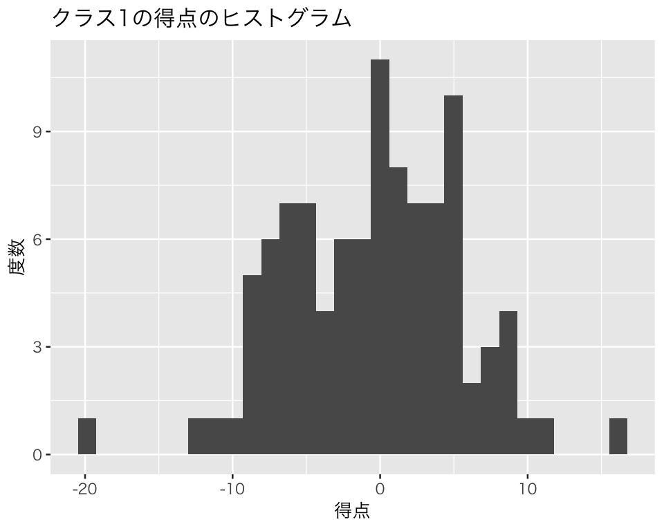

```r
h6 <- ggplot(df2, aes(x = v1)) +
    geom_histogram() +
    labs(x = "得点", y = "度数", title = "クラス1の得点のヒストグラム")
plot(h6)
```

これまでの例からわかる通り、ggplot2 を用いた作図で新しい層を付け加えるときは、1つずつ加えてもよいし、全部同時に加えてもよい。

## 作成した図の保存

作成した図は、PDFファイルやPNGファイルなどの外部ファイルに保存することができる。プロジェクト内に、図を保存するための **figs** とういディレクトリ（フォルダ）を新たに作り、図をその中に保存しよう。

```r
dir.create("figs")
```

基本的には、以下の3つのステップで図を保存する。

1. 図を保存するためのファイルを開く（作る）
2. 図をファイルに書き込む
3. ファイルを閉じる

これら3つのステップはセットで行う。R Markdown を使っている場合は特に注意が必要で、各ステップを一つずつ実行しても図が保存されない。 そこで、3つのスッテプを一つのコードチャンクの中にまとめて書き、チャンク右上の実行ボタン (Run Current Chunk) をクリックして全てのステップを一挙に実行する必要がある。

**図のファイルを作るときは、あらかじめ図のサイズ（高さと幅）を決めておくことが重要である。いい加減なサイズで図を作り、後で拡大・縮小すると、軸ラベルの文字などが伸びたり縮んだりして汚くなるので、スマートではない**。

Windows とMacでは使う関数がやや異なるので、別々に説明する（Linux については省略 [Linux を使える人は自分で調べられるでしょう]）。

### Windows で図を保存する

**2019-05-09 追記：** 環境によっては、PNGファイルでの保存ができないようだ。

先ほど作ったヒストグラム **h6** を、PDFファイルに保存しよう。図を保存するためのPDFファイルは、`pdf()` で作る。 ファイル名は、hist-h6.pdf にしよう。図の大きさは、A4用紙の半ページよりやや小さくなるように、高さ (height) を4インチ (101.6mm)、幅 (width) を5インチ (127.0mm)にしよう。また、軸ラベルに日本語を使っているので、日本語を表示できるフォントを指定する必要がある。ここでは、**Japan1GothicBBB** を指定する。第1ステップの内容をまとめると、次のようになる（**第1ステップだけで実行しない!!!**）。

```r
pdf(file = "figs/hist-h6.pdf", height = 4, width = 5,
    family = "Japan1GothicBBB")
```

**file** の `figs/` という部分が、figs ディレクトリ（フォルダ）の中にファイルを作ることを指示している。

第2ステップは、第1ステップの直後に`print(h6)` とすればよい。

最後に、ファイルを閉じるために、`dev.off()` を実行する。

以上をまとめると、次のようになる。R Markdown では、以下の**コードチャンクを一挙に実行する必要がある**（Rスクリプトでは、1行ずつ実行してよい）。

```r
pdf(file = "figs/hist-h6.pdf", height = 4, width = 5,
    family = "Japan1GothicBBB")
print(h6)
dev.off()
```

これで図が保存されるはずだ。figsディレクトリの中に、hist-h6.pdf というPDFファイルができていることを確かめよう。また、PDFファイルを開き、図が保存されていることも確認しよう。

同様に、PNGファイルに図を保存してみよう。PNGファイルは、`png()`で作れる。 関数の中で指定する内容は、`pdf()`で使ったもののうち、ファイル名の最後（拡張子）を “.png” に変えるだけでよい。

```r
png(file = "figs/hist-h6.png", height = 4, width = 5,
    family = "Japan1GothicBBB")
print(h6)
dev.off()
```

これで図が保存されるはずだ。figsディレクトリの中に、hist-h6.png というPNGファイルができていることを確かめよう。また、PNGファイルを開き、図が保存されていることも確認しよう。

### Mac で図を保存する

Mac で図を保存するには、`quartz()` という関数を使うのが便利でる。 先ほど作ったヒストグラム **h6** を、PDFファイルに保存しよう。 ファイル名は、hist-h6.pdf にしよう。PDFファイルで保存するために、`type = "pdf"` を指定する。 図の大きさは、A4用紙の半ページよりやや小さくなるように、高さ (height) を4インチ (101.6mm)、幅 (width) を5インチ (127.0mm)にしよう。また、軸ラベルに日本語を使っているので、日本語を表示できるフォントを指定する必要がある。ここでは `family = "sans"` （サンセリフ体）を指定しよう。上で`library("tidyverse")` を実行した直後に、`theme_set()` で **HiraginoSans-W3** を指定したので、ヒラギノ角ゴシックが使われる。 第1ステップの内容をまとめると、次のようになる（**第1ステップだけで実行しない!!!**）。

```r
quartz(file = "figs/hist-h6.pdf", type = "pdf", height = 4, width = 5,
       family = "sans")
```

**file** の `figs/` という部分が、figs ディレクトリ（フォルダ）の中にファイルを作ることを指示している。

第2ステップは、第1ステップの直後に`print(h6)` とすればよい。

最後に、ファイルを閉じるために、`dev.off()` を実行する。

以上をまとめると、次のようになる。R Markdown では、以下の**コードチャンクを一挙に実行する必要がある**（Rスクリプトでは、1行ずつ実行してよい）。

```r
quartz(file = "figs/hist-h6.pdf", type = "pdf", height = 4, width = 5,
       family = "sans")
print(h6)
dev.off()
```

これで図が保存されるはずだ。figsディレクトリの中に、hist-h6.pdf というPDFファイルができていることを確かめよう。また、PDFファイルを開き、図が保存されていることも確認しよう。

同様に、PNGファイルに図を保存してみよう。PNGファイルを作るためには、`type = "png"` を指定し、 ファイル名の最後（拡張子）を “.png” に変えるだけでよい。

```r
quartz(file = "figs/hist-h6.png", type = "png", height = 4, width = 5,
       family = "sans")
print(h6)
dev.off()
```

これで図が保存されるはずだ。figsディレクトリの中に、hist-h6.png というPNGファイルができていることを確かめよう。また、PNGファイルを開き、図が保存されていることも確認しよう。

# よく使う図の作り方

ggplotの使い方を身につけるために、統計学でよく使う基本的な図を作ってみよう。

例として、fake-score.csv という架空のデータを使おう。このデータに含まれる変数は、以下の通りである。

- id: 個人識別番号。
- class: クラス。1組から8組まで。
- gender: 性別。女 (female) か男 (male) か。
- math: 数学の試験の得点。
- english: 英語の試験の得点。
- chemistry: 化学の試験の得点。

まず、データを保存するためのディレクトリを作る。既にプロジェクト内に data ディレクトリがある場合、このコマンドは実行しなくてよい。

```r
dir.create("data")
```

次に、データをダウンロードする。

```r
download.file(url = "http://yukiyanai.github.io/jp/classes/stat2/contents/data/fake-score.csv",
              destfile = "data/fake-score.csv")
```

データを読み込む。

```r
myd <- read_csv("data/fake-score.csv")
```

データの中身を確認する。

```r
glimpse(myd)
```

```
## Observations: 400
## Variables: 6
## $ id        <dbl> 1, 2, 3, 4, 5, 6, 7, 8, 9, 10, 11, 12, 13, 14, 15, 16,…
## $ class     <dbl> 1, 1, 1, 1, 1, 1, 1, 1, 1, 1, 1, 1, 1, 1, 1, 1, 1, 1, …
## $ gender    <chr> "female", "female", "female", "female", "female", "fem…
## $ math      <dbl> 100, 43, 80, 52, 63, 45, 74, 54, 59, 74, 65, 41, 71, 7…
## $ english   <dbl> 68, 59, 67, 60, 72, 59, 69, 66, 72, 73, 77, 52, 69, 65…
## $ chemistry <dbl> 97, 60, 75, 60, 57, 67, 62, 63, 69, 67, 70, 48, 59, 76…
```

正しくデータが読み込めたようだ。このデータを使い、作図の方法を学習しよう。

## 棒グラフ

棒グラフ (bar_plot) は `geom_bar()` で作る。まず、クラスごとの人数を棒グラフにしてみよう。 横軸にクラス、縦軸にはクラスの人数を表示する。そのために、次のコマンドを使う。

```r
bar1 <- ggplot(myd, aes(x = class)) +
    geom_bar() +
    labs(x = "クラス", y = "人数")
```

表示してみよう。

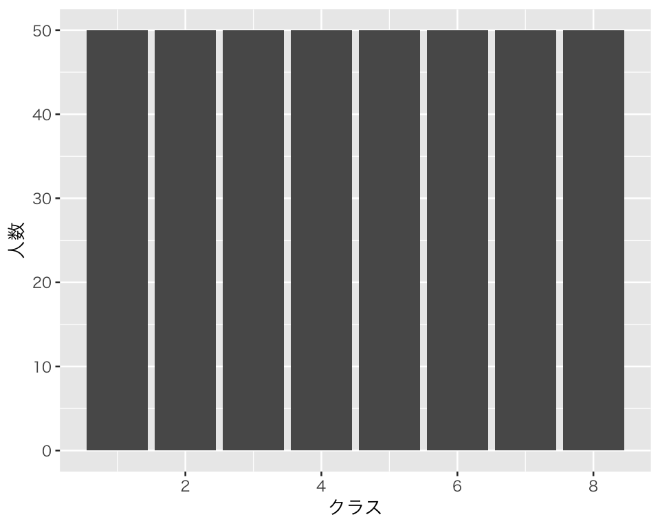

```r
plot(bar1)
```

各クラスの人数が、等しく50人ずつであることがわかる。

横軸のクラスの数字1から8のうち、表示されていない数字がある。`scale_x_continuous()` を使って、すべて表示させよう。**既に作った bar1 を基に**、新しい図を作る。

```r
bar2 <- bar1 + scale_x_continuous(breaks = 1:8)
```

表示してみよう。

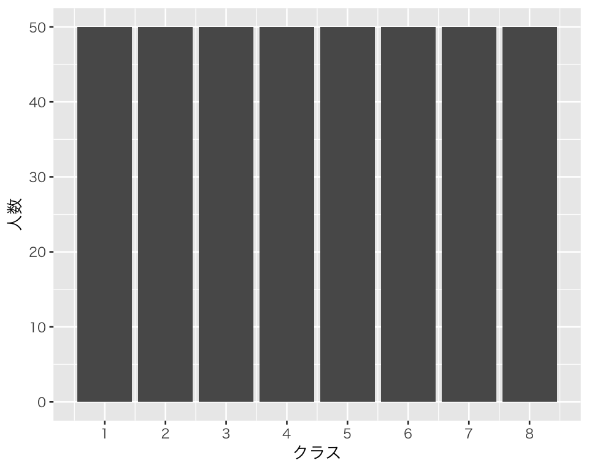

```r
plot(bar2)
```

クラスの数字をすべて表示することができた。

男女の内訳はどうなっているだろうか。男女を色分けして描き、図で確かめよう。 データセットに含まれる gender という変数を使って色分けするために、**aes** の中で **fill** を指定する。

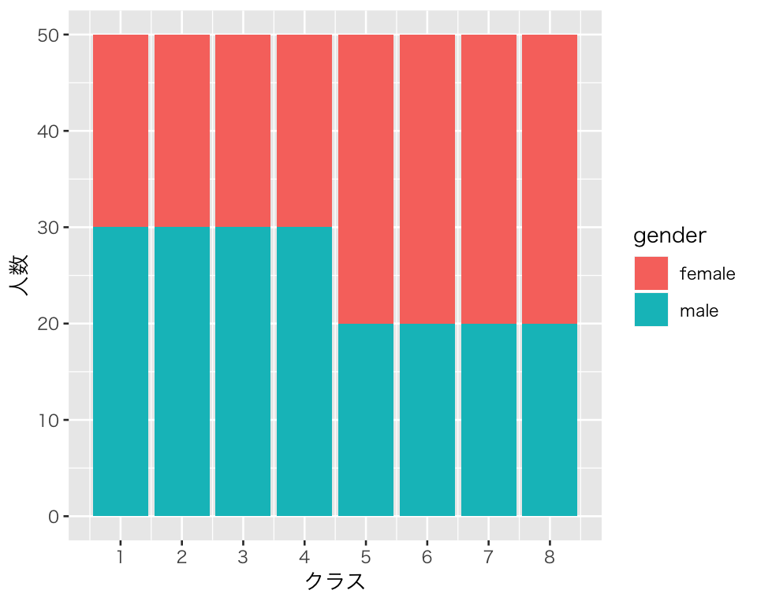

```r
bar3 <- ggplot(myd, aes(x = class, fill = gender)) +
    geom_bar() +
    labs(x = "クラス", y = "人数") +
    scale_x_continuous(breaks = 1:8)
plot(bar3)
```

女子の方が多いクラスと男子の方が多いクラスがあるようだ。 凡例 (legend) が英語になっているので、日本語に直そう。

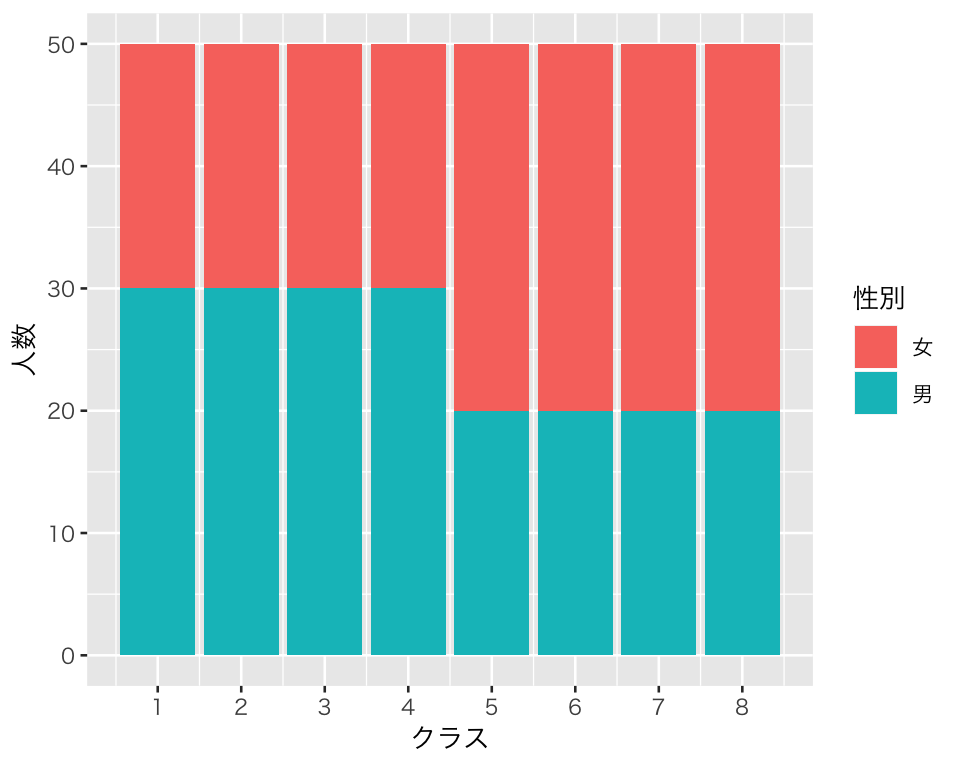

```r
bar4 <- bar3 +
    scale_fill_discrete(name = "性別", labels = c("女", "男"))
plot(bar4)
```

この棒グラフでは男女の数の比較が難しいので、男女の棒を並べて描きたい。そのために、`position = "dodge"` を指定する。

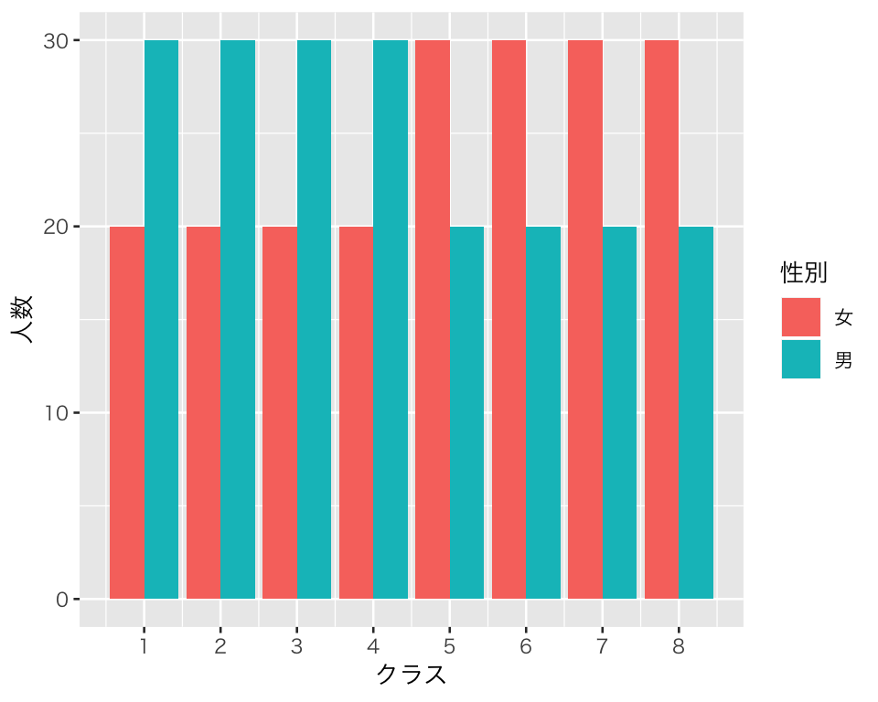

```r
bar5 <-  ggplot(myd, aes(x = class, fill = gender)) +
    geom_bar(position = "dodge") +
    labs(x = "クラス", y = "人数") +
    scale_x_continuous(breaks = 1:8) +
    scale_fill_discrete(name = "性別", labels = c("女", "男"))
plot(bar5)
```

これで、クラス1からクラス4までは女子が20人で男子が30人だが、残りのクラスでは男女の数が逆転していることがわかる。

## ヒストグラム

ヒストグラム (histogram) は、ある変数の分布の仕方を確かめる際に最も便利な図である。 既に説明した通り、ヒストグラムを作るには `geom_histogram()` を使う。

### 基本的な使い方

まず、数学の点数をヒストグラムにしてみよう。

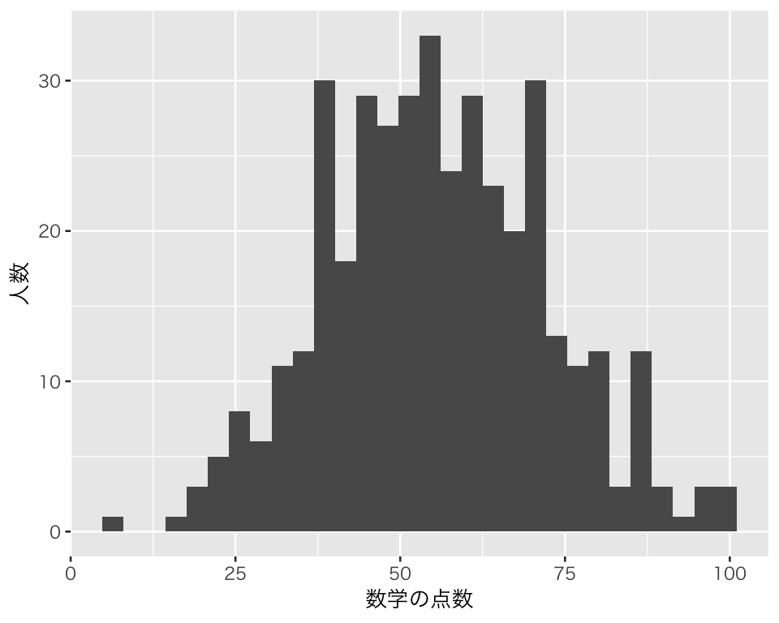

```r
hist1 <- ggplot(myd, aes(x = math)) +
    geom_histogram() +
    labs(x = "数学の点数", y = "人数")
plot(hist1)
```

このままだと、ヒストグラムの一つひとつの棒 (bin) の区切りが分かりにくいので、棒の縁に色をつけよう。 縁取りの色は、**color** で指定する。このとき、変数によって色を変えるのではなく、自分で設定した色を使うため、**aesの外で** color を指定する（上での棒グラフの例では、aesの中で fill を指定した）。

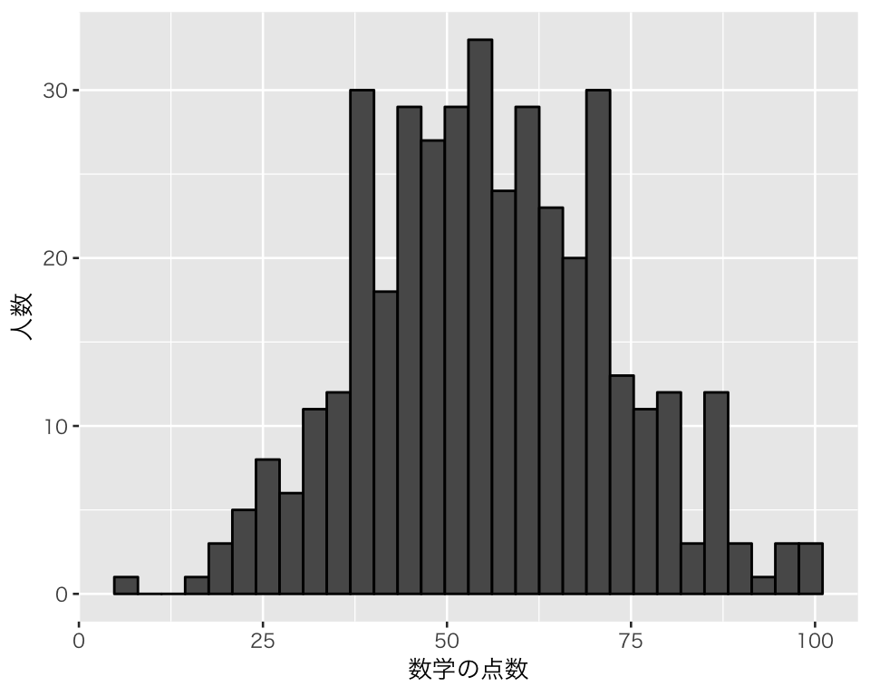

```r
hist2 <- ggplot(myd, aes(x = math)) +
    geom_histogram(color = "black") +
    labs(x = "数学の点数", y = "人数")
plot(hist2)
```

次に棒の幅 (bin width) を変えてみよう。**binwidth** を指定することで、棒の幅を設定できる。試しに、10点ごとにしてみよう。

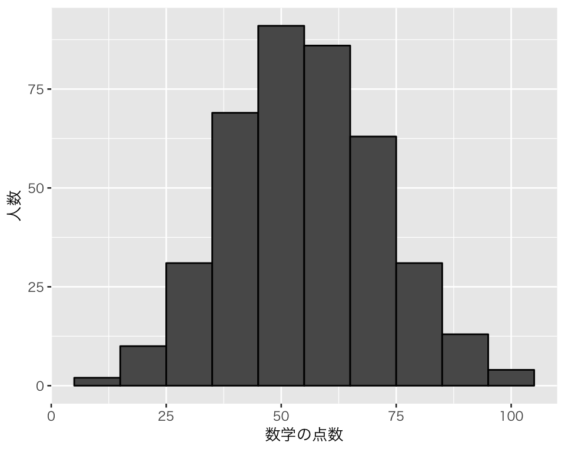

```r
hist3 <- ggplot(myd, aes(x = math)) +
    geom_histogram(color = "black", binwidth = 10) +
    labs(x = "数学の点数", y = "人数")
plot(hist3)
```

### 縦軸を確率密度に変える

ここまでは、度数（数学の点数の場合は人数）を縦軸にしたヒストグラムを作ってきたが、ヒストグラムの縦軸として確率密度 (density) を使うこともできる。そのために、**aesの中で** `y = ..density..` を指定する。 “density” の前後に、それぞれピリオドを2つずつ付けるのがポイントである。これは、“density” というのはデータフレームに含まれる変数ではなく、データを基にggplotが計算するものであることを示している。

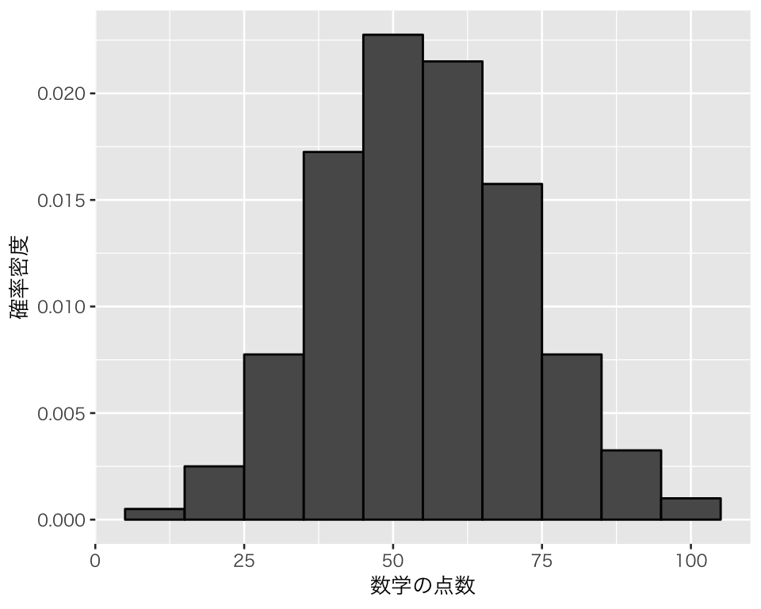

```r
hist4 <- ggplot(myd, aes(x = math, y = ..density..)) +
    geom_histogram(color = "black", binwidth = 10) +
    labs(x = "数学の点数", y = "確率密度")
plot(hist4)
```

縦軸が確率密度のヒストグラムができた。

### 複数の geom を重ねる

数学の点数の平均値は、

```r
mean(myd$math)
```

```
## [1] 55.6
```

である。これを図に書き加えよう。

まず、`geom_vline()` で、平均値の位置に縦線を加える。 vlineの**v** はvertical（垂直）を示す。 `geom_vline()`で縦線の位置を決めるために、**xintercept**（x切片、つまり、線が横軸と交わる位置）を指定する。

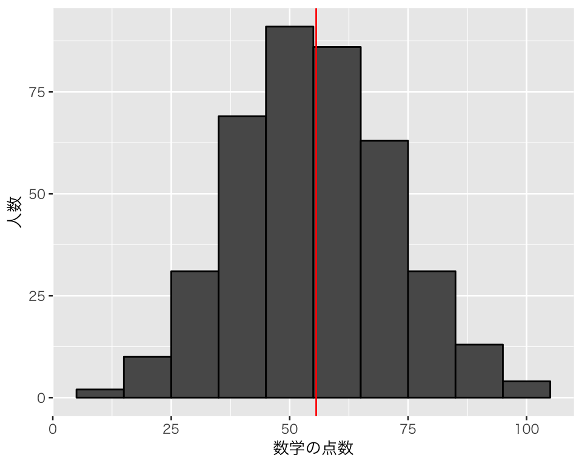

```r
hist5 <- hist3 + geom_vline(xintercept = mean(myd$math), color = "red")
plot(hist5)
```

次に、平均値の値を（小数第一位までに四捨五入 [round] して）書き込む。

Windows用のコード：

```r
hist6 <- hist5 +
    geom_text(aes(x = 70, y = 90,
                  label = str_c("平均値：", round(mean(myd$math), 1))),
              color = "red")
```

Mac用のコード：

```r
hist6 <- hist5 +
    geom_text(aes(x = 70, y = 90,
                  label = str_c("平均値：", round(mean(myd$math), 1))),
              color = "red", family = "HiraginoSans-W3")
```

表示する。

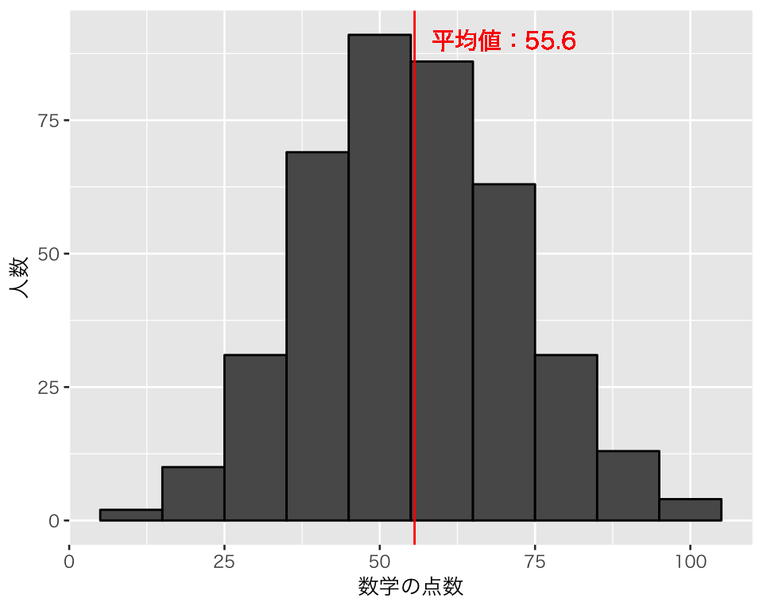

```r
plot(hist6)
```

### facet でグループを分ける

数学の点数のヒストグラムを、クラスごとに分けて描いてみよう。そのために、`facet_wrap()` を使う

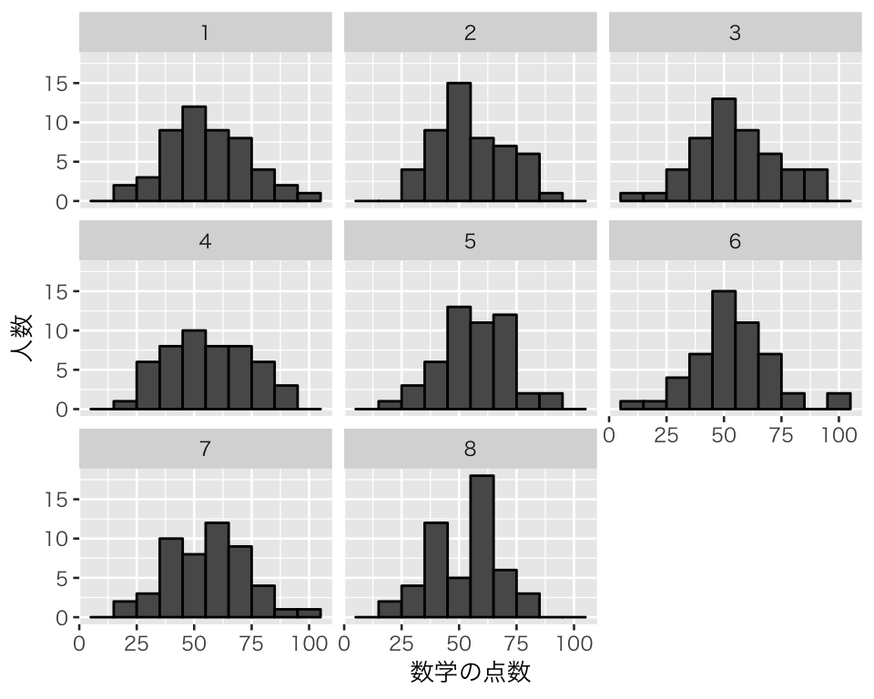

```r
hist7 <- hist3 + facet_wrap(. ~ class)
plot(hist7)
```

このように、クラスごとにヒストグラムができる。

## 箱ひげ図、バイオリンプロット、ビースウォームプロット

### 箱ひげ図

ヒストグラムは分布の形状を確かめるのに便利だが、上で作った hist7 のように、複数のグループの分布を比較するのには少し不便である。 そこで異なるグループの分布を比較するときによく使われるのが、箱ひげ図 (box[-and-whisker] plot) である。箱ひげ図は、五数要約（最小値、第1四分位数、中央値、第3四分位数、最大値）と外れ値（「1.5 $\times$ IQRルール」で判定される）を図で表現するものである。

箱ひげ図は、`geom_boxplot()` で作る。このとき、aes には **x**（比較するグループを表す変数）と**y**（作図の対象となる変数）を指定する（xの代わりに **group** を使うこともできる）。ここで、class の中身の数字には数値としての意味はなく、単にクラス分けのための記号にすぎないことを gpplotに伝えるために `as.factor()` を使う（本当はデータ前処理の時点で id と class は factor にしておくことが望ましいが、今回はこれで妥協する）。

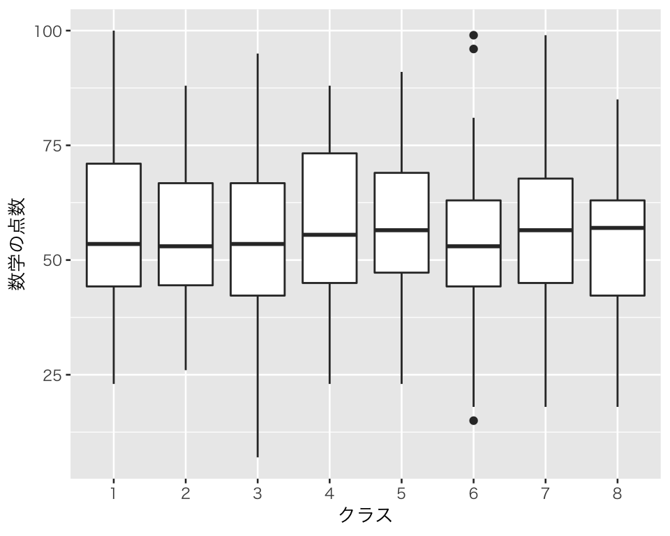

```r
box1 <- ggplot(myd, aes(x = as.factor(class), y = math)) +
    geom_boxplot() +
    labs(x = "クラス", y = "数学の点数")
plot(box1)
```

これで、グループ間で数学の点数の五数を比較しやすくなった。

##＃ バイオリンプロット

箱ひげ図でグループ間比較がしやすくなったが、ヒストグラムとは異なり、分布の形状がわからなくなってしまった。この不満を解消してくれるのが、バイオリンプロット (violin plot) である。`geom_violin()` で作る。

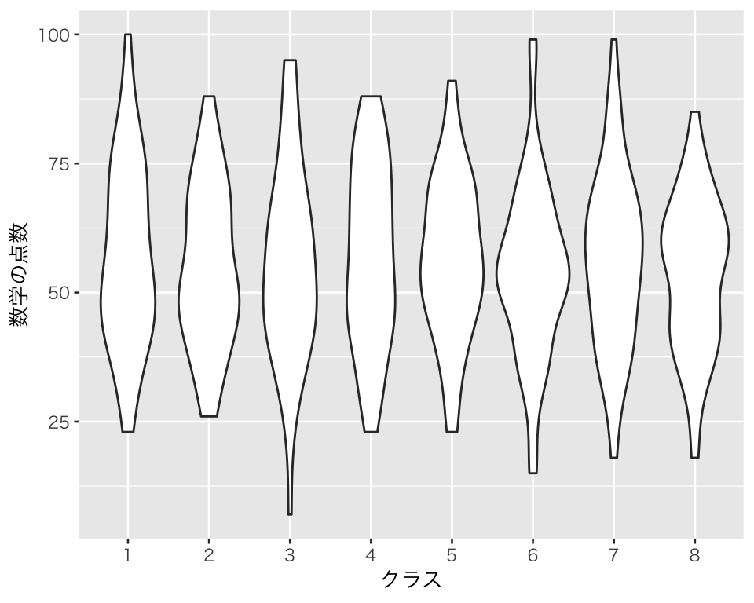

```r
vln1 <- ggplot(myd, aes(x = as.factor(class), y = math)) +
    geom_violin() +
    labs(x = "クラス", y = "数学の点数")
plot(vln1)
```

この図は、ヒストグラムを横倒しにしてその概形を滑らかな線で表したものと、それを鏡に写したものが合わさってできている。バイオリンプロットの幅が広い（狭い）ところが、ヒストグラムの山が高い（低い）ところである。

### 箱ひげ図とバイオリンプロットの重ね描き

バイオリンプロットは、分布の形状がわからないという箱ひげ図の弱点を克服しているものの、箱ひげ図では一目でわかった中央値や四分位範囲がわからないという弱点がある。両者の長所を活かすため、二つの図を重ねて描いてみよう。

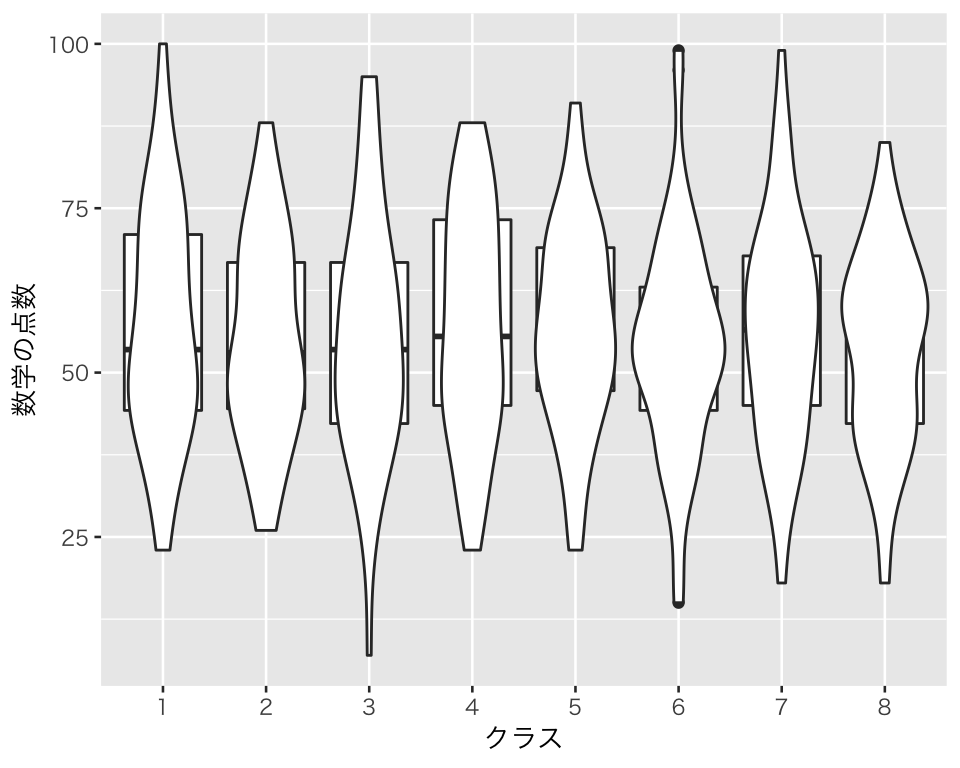

```r
bv1 <- ggplot(myd, aes(x = as.factor(class), y = math)) +
    geom_boxplot() +
    geom_violin() +
    labs(x = "クラス", y = "数学の点数")
plot(bv1)
```

バイロリンプロットが箱ひげ図の線に重なり、箱ひげ図がよく見えない。箱ひげ図をバイオリンプロットの上に（手前に）描いた方がよさそうだ。ggplotでは、後に加えた要素（層）が上になるので、`geom_violin()` の後に `geom_boxplot()` を書く。

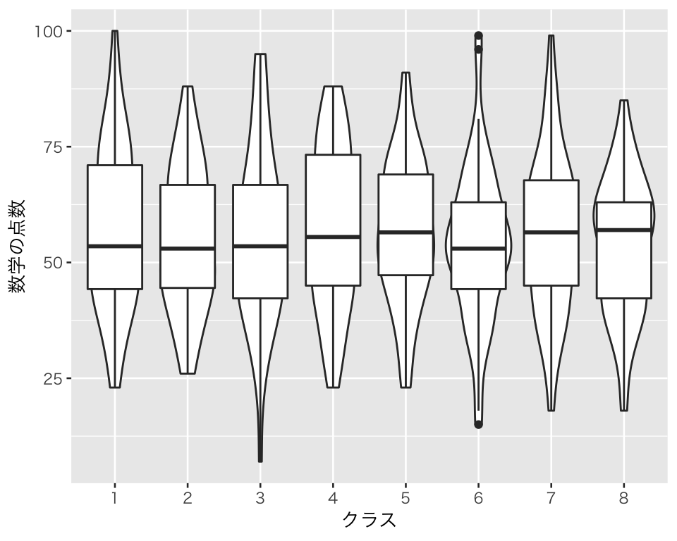

```r
bv2 <- ggplot(myd, aes(x = as.factor(class), y = math)) +
    geom_violin() +
    geom_boxplot() +
    labs(x = "クラス", y = "数学の点数")
plot(bv2)
```

今度は、箱がバイオリンの線をに重なってしまっている。`geom_boxplot()` で **width** を指定し、箱の幅を狭くしてみよう。

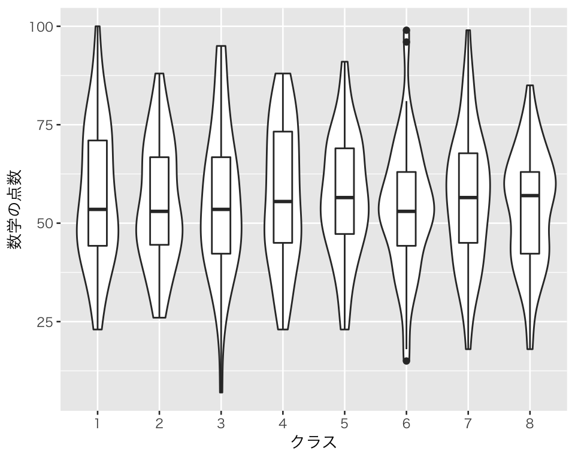

```r
bv3 <- ggplot(myd, aes(x = as.factor(class), y = math)) +
    geom_violin() +
    geom_boxplot(width = 0.3) +
    labs(x = "クラス", y = "数学の点数")
plot(bv3)
```

これで、箱ひげ図とバイロリンプロットが同時に確認できるようになった。しかし、このままでは箱ひげ図が目立たないので、色を変えよう。

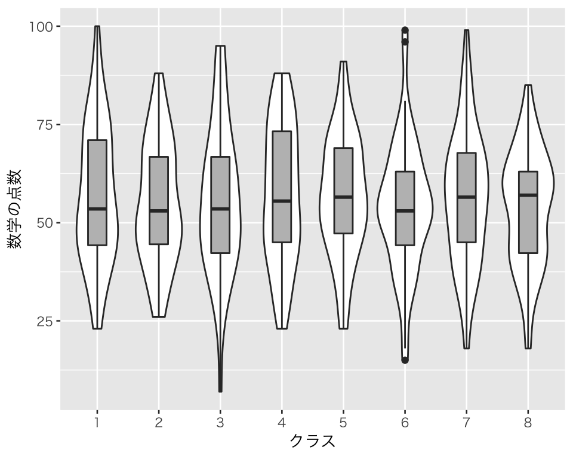

```r
bv4 <- ggplot(myd, aes(x = as.factor(class), y = math)) +
    geom_violin() +
    geom_boxplot(width = 0.3, fill = "gray") +
    labs(x = "クラス", y = "数学の点数")
plot(bv4)
```

この図を見れば、数学の点数の分布をクラス間で比較できる。

### ビースウォームプロット（蜂群図）

箱ひげ図とバイオリンプロットで、グループ間の分布を比較できるようになった。しかし、観測値が実際にどの値をとったかはわからない。この問題を克服するために使われるのが、ビースウォームプロット (bee swarm plot) である。

ggplotを使ってビースウォームプロットを描くには、**ggbeeswarm** というパッケージを導入するのが簡単だ。 まず、インストールする（既にインストール済みなら、このコマンドは実行しなくてよい）。

```r
install.packages("ggbeeswarm")
```

インストールが済んだら、パッケージを読み込む。

```r
library("ggbeeswarm")
```

ビースウォームプロットは、`geom_beeswarm()`または`geom_quasirandom()` で描く。 これら二つの違いは、点の散らし方である。実際に作って比べてみよう。

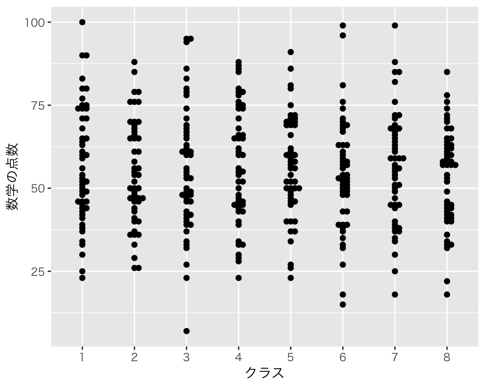

```r
bee1 <- ggplot(myd, aes(x = as.factor(class), y = math)) +
    geom_beeswarm() +
    labs(x = "クラス", y = "数学の点数")
plot(bee1)
```

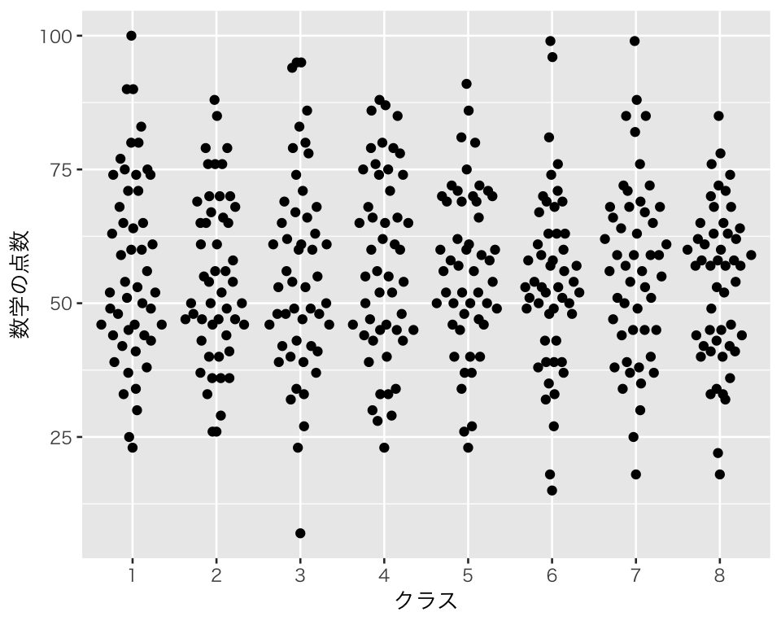

```r
bee2 <- ggplot(myd, aes(x = as.factor(class), y = math)) +
    geom_quasirandom() +
    labs(x = "クラス", y = "数学の点数")
plot(bee2)
```

ビースウォームプロットでは、全く同じか近い値をとった観測値が重ならないよう、点を散らして (jittering) くれる。その散らし方が、二つの geom で異なる。

これらの図により、分布の中で実際に観測値がどこにあるかが明らかになった。ビースウォームプロットを、箱ひげ図とバイロリンプロットに重ねてみよう。

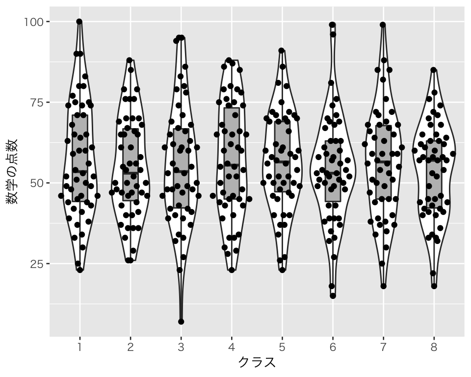

```r
bee3 <- bv4 + geom_quasirandom()
plot(bee3)
```

点のせいで箱ひげ図がの線が見えにくいなら、(1) 点の色を変えるか、(2) 点の透明度を上げてみよう。透明度は alpha で指定する。`alpha = 1/3` とすると、点が3つ重なったときに透明度が0になるなるようになる。

両方同時にやってみよう。

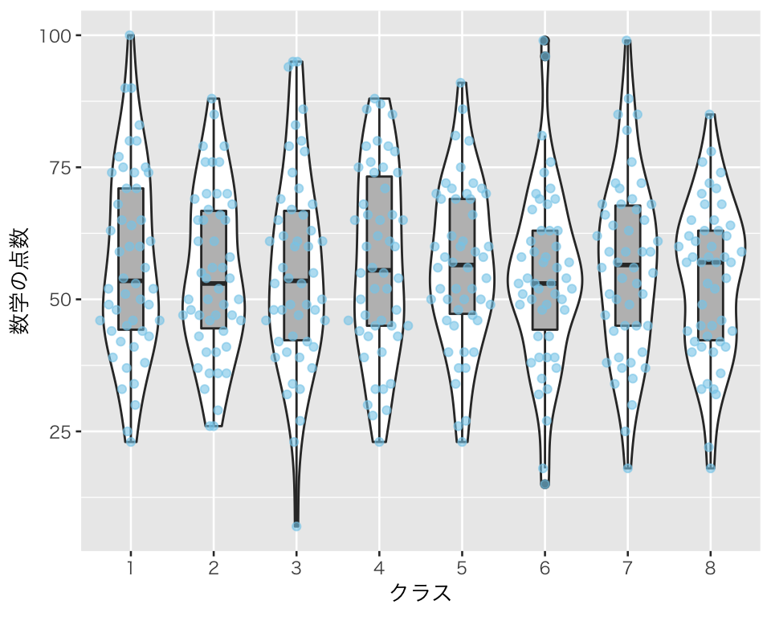

```r
bee4 <- bv4 +
    geom_quasirandom(color = "skyblue", alpha = 3/5)
plot(bee4)
```

男女の点の色を変えてみよう。

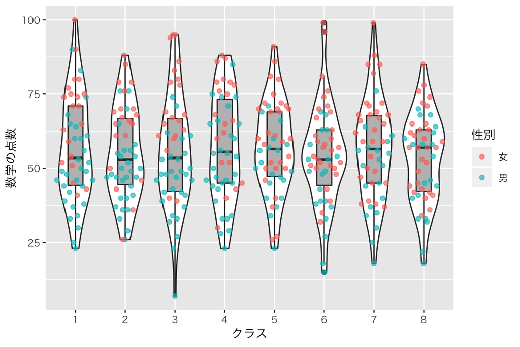

```r
bee5 <- bv4 +
    geom_quasirandom(aes(color = gender), alpha = 2/3) +
    scale_color_discrete(name = "性別", labels = c("女", "男"))
plot(bee5)
```

これで、分布の形状と五数だけでなく、実際の観測値がどこにあるかまで明らかにできた。

## 散布図

ここまでは、1つの変数を可視化するグラフを作ってきた。続いて、2変数の関係を可視化してみよう。

2変数（2つの量的変数）の関係を可視化するための最も基本的な図は散布図 (scatter plot) である。散布図は、`geom_point()` で作る。散布図のaesには、横軸の変数 x と縦軸の変数 y を指定する。

数学の点数（横軸）と英語の点数（縦軸）の関係を散布図にしみてよう。

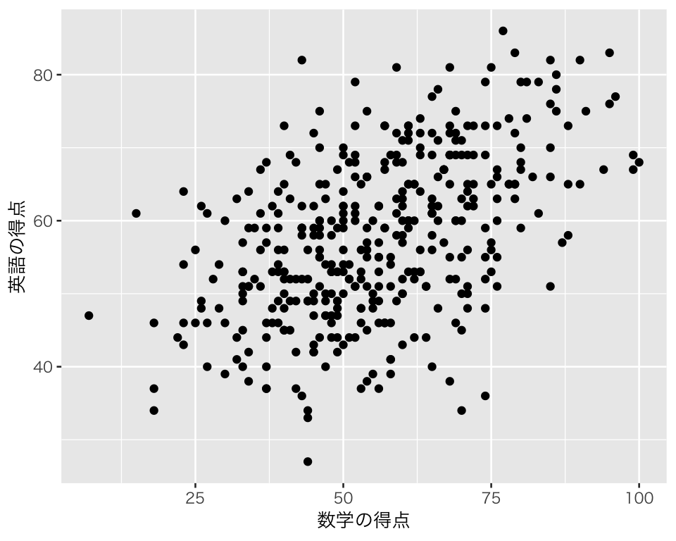

```r
scat1 <- ggplot(myd, aes(x = math, y = english)) +
    geom_point() +
    labs(x = "数学の得点", y = "英語の得点")
plot(scat1)
```

英語も数学も100点満点の試験なのに、図が横長になっていて数学の得点の範囲の方が広く見えてしまう。 この点を改善するために、`xlim()` と `ylim()` で横軸と縦軸の範囲を指定し、`coord_fixed(ratio = 1)` で縦横比を1:1にしよう（ratio = 1 はデフォルトなので、単に `coord_fixed()` でもいいが、比がはっきりわかるようにここでは明示しておく）。

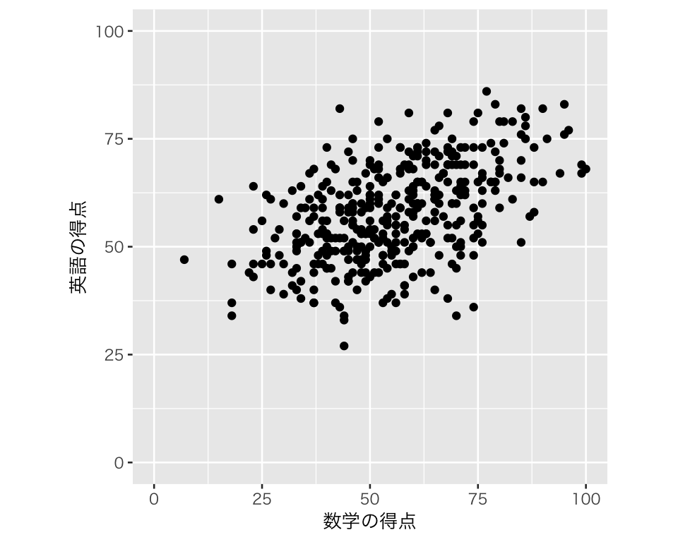

```r
scat2 <- scat1 + xlim(0, 100) + ylim(0, 100) +
    coord_fixed(ratio = 1)
plot(scat2)
```

男女の点を、色 (color) と形 (shape) で区別してみよう。

まず、色で区別する。

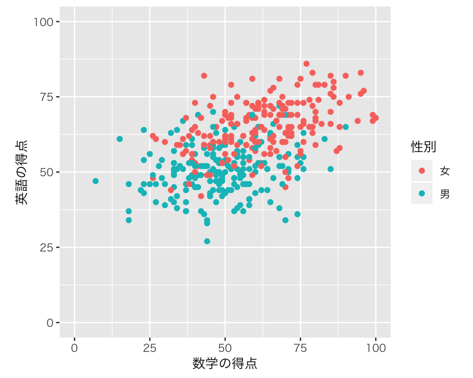

```r
scat3 <- ggplot(myd, aes(x = math, y = english, color = gender)) +
    geom_point() +
    labs(x = "数学の得点", y = "英語の得点") +
    scale_color_discrete(name = "性別", labels = c("女", "男")) +
    xlim(0, 100) + ylim(0, 100) + coord_fixed(ratio = 1)
plot(scat3)
```

次に、形で区別する。

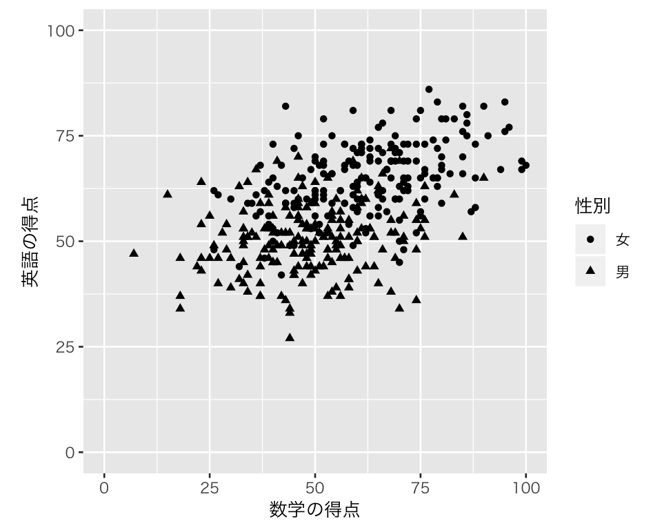

```r
scat4 <- ggplot(myd, aes(x = math, y = english, shape = gender)) +
    geom_point() +
    labs(x = "数学の得点", y = "英語の得点") +
    scale_shape_discrete(name = "性別", labels = c("女", "男")) +
    xlim(0, 100) + ylim(0, 100) + coord_fixed(ratio = 1)
plot(scat4)
```

最後に、色と形で区別する。

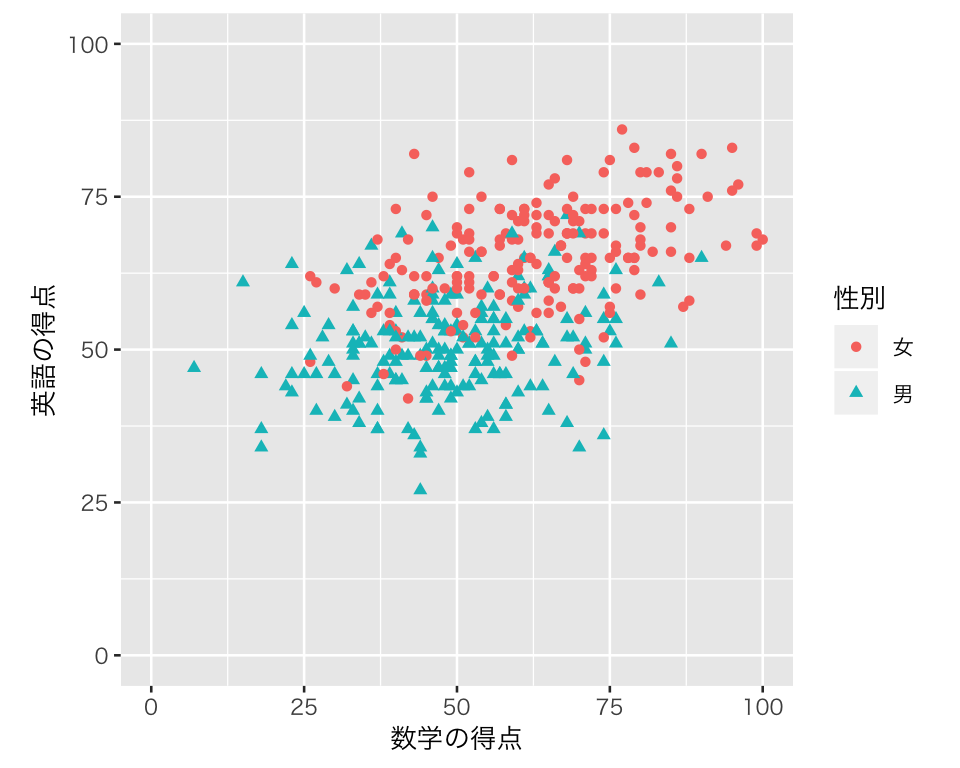

```r
scat5 <- ggplot(myd, aes(x = math, y = english, color = gender, shape = gender)) +
    geom_point() +
    labs(x = "数学の得点", y = "英語の得点") +
    scale_color_discrete(name = "性別", labels = c("女", "男")) +
    scale_shape_discrete(name = "性別", labels = c("女", "男")) +
    xlim(0, 100) + ylim(0, 100) + coord_fixed(ratio = 1)
plot(scat5)
```

このように、ggplot2を使えば**簡単**に**綺麗**な図を作ることができる。

慣れるまではggplot2での作図を面倒に感じるかもしれないが、慣れてしまえばggplotが手放せなくなるだろう。

授業の内容に戻る  
[『Rによる計量政治学』のサポートページに戻る](https://github.com/yukiyanai/quant-methods-R)